# Analysis_AETv3

Author

Nikita

## Loading the data

```r
library(tidyverse)
library(dplyr)

#Effort data
aetv3_beh_tib <- here::here("data", "v3", "behav_summary_v3.csv") %>%
  readr::read_csv() %>%
  dplyr::filter(!(subjectNumber %in% 1:16)) #excluding the first 16 participants

#Questionnaire data
aetv3_questn_tib <- here::here("data", "v3", "questionnaire_data_v3.csv") %>%
  readr::read_csv() %>%
  #For similarity in subjects numbers in both data sets
  dplyr::mutate(Subject_number = Subject_number - 100) %>%
  dplyr::filter(!(Subject_number %in% 1:16)) #Excluding the first 16 participants- same as effort data
```

## Cleaning the effort data

```r
#Excluding participants with >95% acceptance rates and those based on failed accepted trials
aetv3_beh_tib <- aetv3_beh_tib %>%
  group_by(subjectNumber) %>%
  filter(response != 8888) %>%
  mutate(Mean_response = mean(response)) %>%
  filter(!(Mean_response > 0.95)) %>%
  mutate(failed = timeInWindow < 1) %>%
  mutate(failed = mean(failed, na.rm = T)) %>%
  filter(!(failed > 0.2))

# Removing missed trials and also if first and last trials were missed
aetv3_beh_tib$exertedEffortHistory[is.nan(aetv3_beh_tib$exertedEffortHistory)] <- 0
aetv3_beh_tib$exertedEffortHistory[aetv3_beh_tib$responseHistory == 8888] <- 0

#Calculating the acceptance rate by effort level and environment
aetv3_beh_tib$shapeEffort <- as.factor(aetv3_beh_tib$shapeEffort)
aetv3_beh_tib$blockType <- as.factor(aetv3_beh_tib$blockType)
aetv3_beh_tib_acceptrate <- aetv3_beh_tib %>%
  group_by(subjectNumber, blockType, shapeEffort) %>%
  summarise(acceptRate = mean(response))
#Renaming the Block column to Easy and Hard
aetv3_beh_tib_acceptrate <- aetv3_beh_tib_acceptrate %>%
   dplyr::mutate(blockType = stringr::str_to_sentence(blockType) %>% stringr::str_replace("11", "Easy") %>% stringr::str_replace("99", "Hard"))
```

## Scoring questionnaires + Histograms for each

### Apathy-Motivation Index (AMI)

AMI: High scores indicate greater apathy and low scores indicate greater motivation

```r
#Selecting the columns for AMI
AMI_v3 <- aetv3_questn_tib %>%
  dplyr::select(AMI_1:AMI_18)
#Recoding the participant responses (All the items are reverse scored)
recode_AMI_v3 <- c("Completely UNTRUE" = 4, "Mostly untrue" = 3, "Neither true nor untrue" = 2, "Quite true" = 1, "Completely TRUE" = 0)
aetv3_questn_tib <- aetv3_questn_tib %>%
  dplyr::mutate(across(starts_with("AMI_"), ~ifelse(. %in% names(recode_AMI_v3), recode_AMI_v3[.], .))) %>%
  dplyr::mutate(across(starts_with("AMI_"), as.numeric))

#AMI Subscale total scores
#Emotional sensitivity (ES)
AMI_ES_v3 <- c("AMI_1", "AMI_6", "AMI_7", "AMI_13", "AMI_16", "AMI_18")
aetv3_questn_tib <- aetv3_questn_tib %>%
  mutate(AMI_ES_sum_v3 = rowMeans(dplyr::select(., all_of(AMI_ES_v3)), na.rm = TRUE)) #Creating a new column with sum of scores for the ES subscale

#Social motivation (SM)
AMI_SM_v3 <- c("AMI_2", "AMI_3", "AMI_4", "AMI_8", "AMI_14", "AMI_17")
aetv3_questn_tib <- aetv3_questn_tib %>%
  mutate(AMI_SM_sum_v3 = rowMeans(dplyr::select(., all_of(AMI_SM_v3)), na.rm = TRUE)) #Creating a new column with sum of scores for the SM subscale

#Behavioural activation (BA)
AMI_BA_v3 <- c("AMI_5", "AMI_9", "AMI_10", "AMI_11", "AMI_12", "AMI_15")
aetv3_questn_tib <- aetv3_questn_tib %>%
  mutate(AMI_BA_sum_v3 = rowMeans(dplyr::select(., all_of(AMI_BA_v3)), na.rm = TRUE)) #Creating a new column with sum of scores for the BA subscale

#Total- full scale
aetv3_questn_tib <- aetv3_questn_tib %>%
  mutate(AMI_sum_v3 = rowMeans(cbind(AMI_ES_sum_v3, AMI_SM_sum_v3, AMI_BA_sum_v3), na.rm = TRUE))
```

#### Histograms_AMI

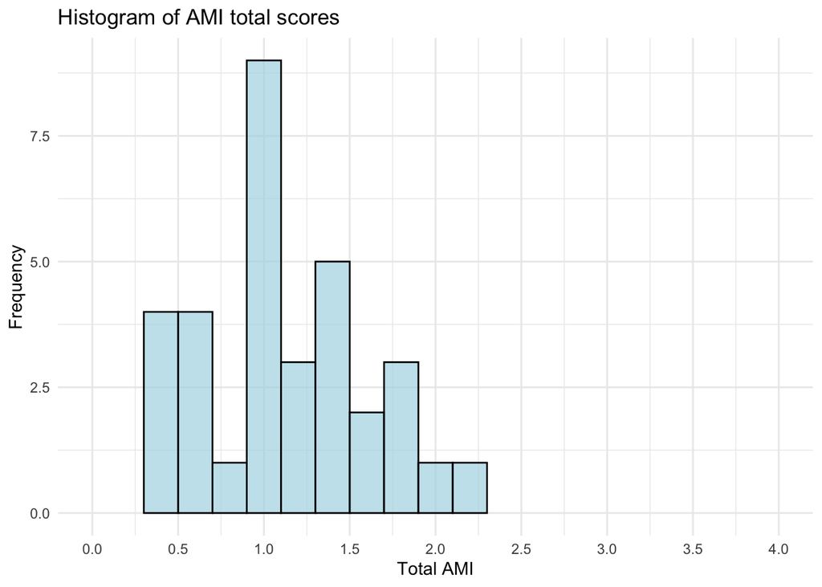

```r
library(ggplot2)
#Full-scale
ggplot(aetv3_questn_tib, aes(x = AMI_sum_v3)) +
  geom_histogram(binwidth = 0.2, fill = "lightblue", color = "black", alpha = 0.7) +
  labs(title = "Histogram of AMI total scores", x = "Total AMI", y = "Frequency") +
  coord_cartesian(xlim = c(0,4)) +
  scale_x_continuous(breaks = seq(0, 4, 0.5)) +
  theme_minimal()
```

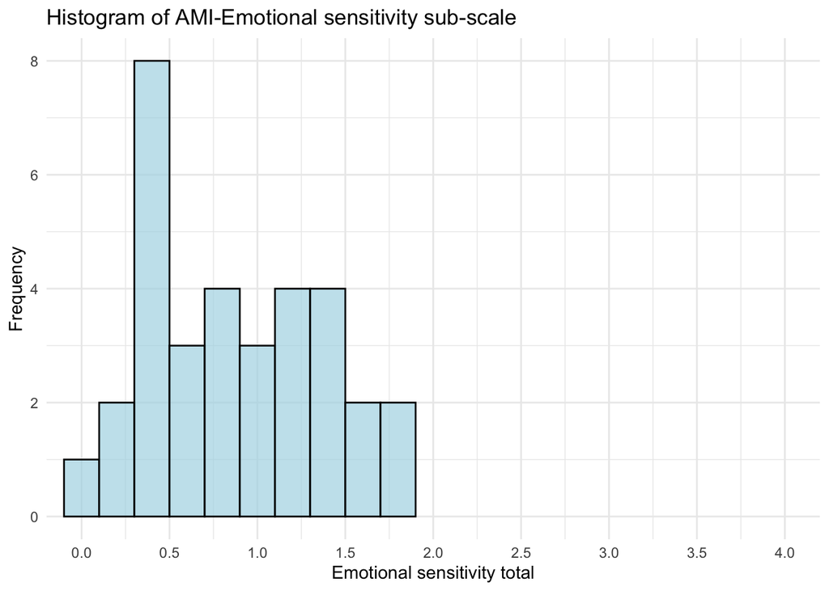

```r
#Emotional sensitivity sub-scale
ggplot(aetv3_questn_tib, aes(x = AMI_ES_sum_v3)) +
  geom_histogram(binwidth = 0.2, fill = "lightblue", color = "black", alpha = 0.7) +
  labs(title = "Histogram of AMI-Emotional sensitivity sub-scale", x = "Emotional sensitivity total", y = "Frequency") +
  coord_cartesian(xlim = c(0,4)) +
  scale_x_continuous(breaks = seq(0, 4, 0.5)) +
  theme_minimal()
```

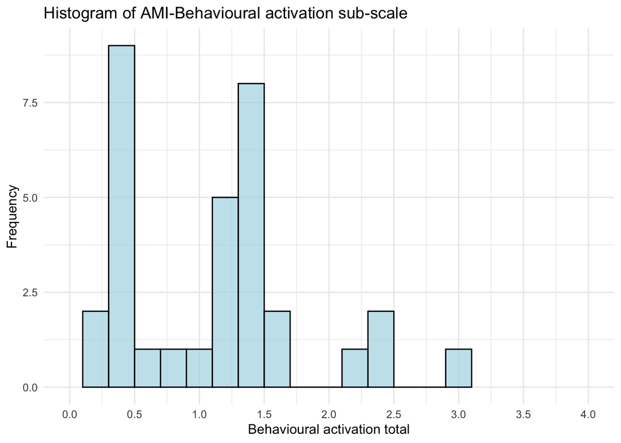

```r
#Behavioural activation sub-scale
ggplot(aetv3_questn_tib, aes(x = AMI_BA_sum_v3)) +
  geom_histogram(binwidth = 0.2, fill = "lightblue", color = "black", alpha = 0.7) +
  labs(title = "Histogram of AMI-Behavioural activation sub-scale", x = "Behavioural activation total", y = "Frequency") +
  coord_cartesian(xlim = c(0,4)) +
  scale_x_continuous(breaks = seq(0, 4, 0.5)) +
  theme_minimal()
```

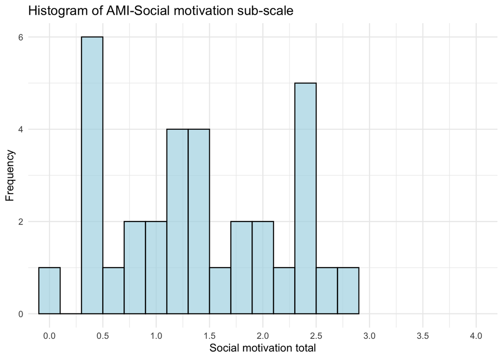

```r
#Social motivation sub-scale
ggplot(aetv3_questn_tib, aes(x = AMI_SM_sum_v3)) +
  geom_histogram(binwidth = 0.2, fill = "lightblue", color = "black", alpha = 0.7) +
  labs(title = "Histogram of AMI-Social motivation sub-scale", x = "Social motivation total", y = "Frequency") +
  coord_cartesian(xlim = c(0,4)) +
  scale_x_continuous(breaks = seq(0, 4, 0.5)) +
  theme_minimal()
```

### Multidimensional Fatigue Inventory (MFI)

MFI: Higher scores indicate higher levels of fatigue

```r
#Selecting the columns for MFI
MFI_v3 <- aetv3_questn_tib %>%
  dplyr::select(MFI_1:MFI_20)

#Recoding the participant responses
recode_MFI_v3 <- c("1 - Yes, that is true" = 1, "5 - No, that is not true" = 5)
aetv3_questn_tib <- aetv3_questn_tib %>%
  mutate(across(starts_with("MFI_"), ~ifelse(. %in% names(recode_MFI_v3), recode_MFI_v3[.], .)))

#Reverse scoring the items
reverse_MFI_v3 <- c("5" = 1, "4" = 2, "3" = 3 ,"2" = 4, "1" = 5)
aetv3_questn_tib <- aetv3_questn_tib %>%
  dplyr::mutate(across(c("MFI_2", "MFI_5", "MFI_9", "MFI_10", "MFI_13", "MFI_14", "MFI_16", "MFI_17", "MFI_18", "MFI_19"),
      ~ recode(., !!!reverse_MFI_v3),
      .names = "reversed_{.col}"))

#Adding up the scores (full-scale)
MFI_all_v3 <- c("MFI_1", "reversed_MFI_2", "MFI_3", "MFI_4", "reversed_MFI_5", "MFI_6", "MFI_7", "MFI_8", "reversed_MFI_9", "reversed_MFI_10","MFI_11", "MFI_12", "reversed_MFI_13", "reversed_MFI_14", "MFI_15", "reversed_MFI_16", "reversed_MFI_17", "reversed_MFI_18", "reversed_MFI_19", "MFI_20")
aetv3_questn_tib <- aetv3_questn_tib %>%
  mutate(across(all_of(MFI_all_v3), as.numeric)) %>%
  mutate(MFI_sum_v3 = rowSums(dplyr::select(., all_of(MFI_all_v3)), na.rm = TRUE))

#MFI Subscale sum
#General fatigue
MFI_genfatigue_v3 <- c("MFI_1", "reversed_MFI_5", "MFI_12", "reversed_MFI_16")
aetv3_questn_tib <- aetv3_questn_tib %>%
  mutate(across(all_of(MFI_genfatigue_v3), as.numeric)) %>%
  mutate(MFI_genfatigue_sum_v3 = rowSums(dplyr::select(., all_of(MFI_genfatigue_v3)), na.rm = TRUE))

#Physical fatigue
MFI_phyfatigue_v3 <- c("reversed_MFI_2", "MFI_8", "reversed_MFI_14", "MFI_20")
aetv3_questn_tib <- aetv3_questn_tib %>%
  mutate(across(all_of(MFI_phyfatigue_v3), as.numeric)) %>%
  mutate(MFI_phyfatigue_sum_v3 = rowSums(dplyr::select(., all_of(MFI_phyfatigue_v3)), na.rm = TRUE))

#Reduced activity
MFI_redactivity_v3 <- c("MFI_3", "MFI_6", "reversed_MFI_10", "reversed_MFI_17")
aetv3_questn_tib <- aetv3_questn_tib %>%
  mutate(across(all_of(MFI_redactivity_v3), as.numeric)) %>%
  mutate(MFI_redactivity_sum_v3 = rowSums(dplyr::select(., all_of(MFI_redactivity_v3)), na.rm = TRUE))

#Reduced motivation
MFI_redmotn_v3 <- c("MFI_4", "reversed_MFI_9", "MFI_15", "reversed_MFI_18")
aetv3_questn_tib <- aetv3_questn_tib %>%
  mutate(across(all_of(MFI_redmotn_v3), as.numeric)) %>%
  mutate(MFI_redmotn_sum_v3 = rowSums(dplyr::select(., all_of(MFI_redmotn_v3)), na.rm = TRUE))

#Mental fatigue
MFI_mentalfatigue_v3 <- c("MFI_7", "MFI_11", "reversed_MFI_13", "reversed_MFI_19")
aetv3_questn_tib <- aetv3_questn_tib %>%
  mutate(across(all_of(MFI_mentalfatigue_v3), as.numeric)) %>%
  mutate(MFI_mentalfatigue_sum_v3 = rowSums(dplyr::select(., all_of(MFI_mentalfatigue_v3)), na.rm = TRUE))
```

#### Histograms_MFI

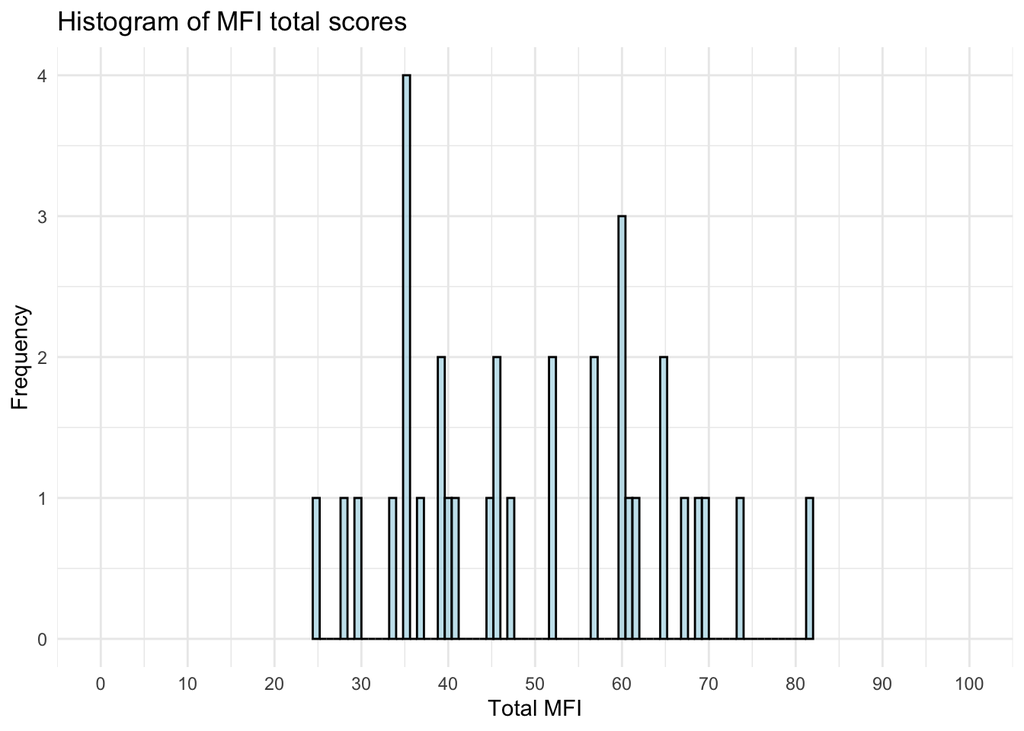

```r
#Full-scale
ggplot(aetv3_questn_tib, aes(x = MFI_sum_v3)) +
  geom_histogram(binwidth = 0.8, fill = "lightblue", color = "black", alpha = 0.7) +
  labs(title = "Histogram of MFI total scores", x = "Total MFI", y = "Frequency") +
  coord_cartesian(xlim = c(0,100)) +
  scale_x_continuous(breaks = seq(0, 100, 10)) +
  theme_minimal()
```

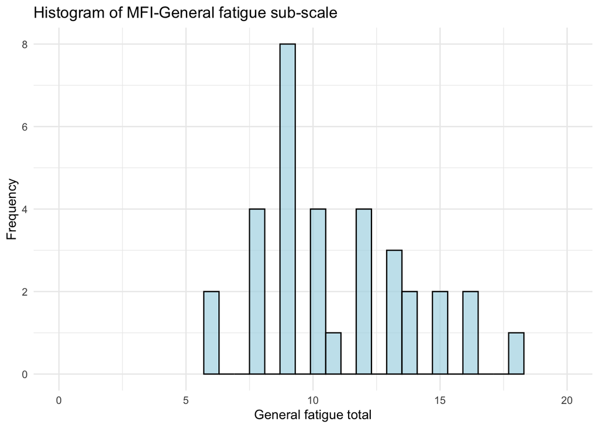

```r
#General fatigue sub-scale
ggplot(aetv3_questn_tib, aes(x = MFI_genfatigue_sum_v3)) +
  geom_histogram(binwidth = 0.6, fill = "lightblue", color = "black", alpha = 0.7) +
  labs(title = "Histogram of MFI-General fatigue sub-scale", x = "General fatigue total", y = "Frequency") +
  coord_cartesian(xlim = c(0,20)) +
  scale_x_continuous(breaks = seq(0, 20, 5)) +
  theme_minimal()
```

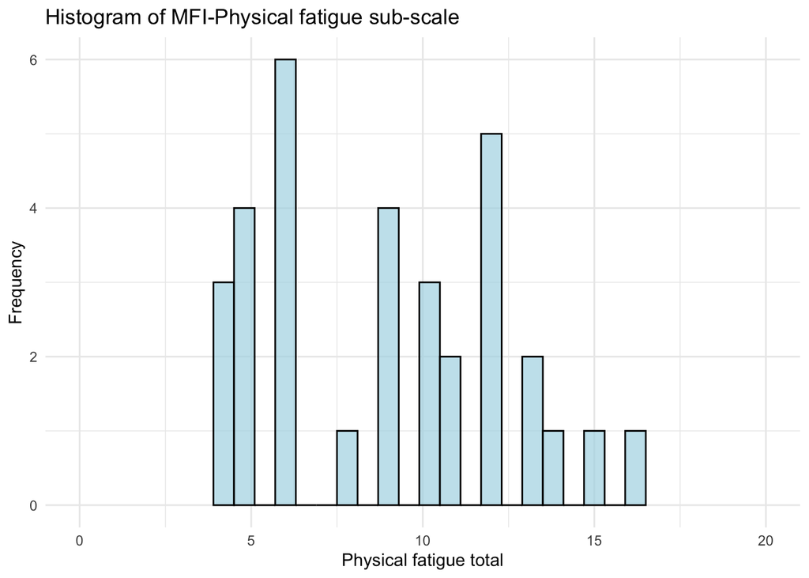

```r
#Physical fatigue sub-scale
ggplot(aetv3_questn_tib, aes(x = MFI_phyfatigue_sum_v3)) +
  geom_histogram(binwidth = 0.6, fill = "lightblue", color = "black", alpha = 0.7) +
  labs(title = "Histogram of MFI-Physical fatigue sub-scale", x = "Physical fatigue total", y = "Frequency") +
  coord_cartesian(xlim = c(0,20)) +
  scale_x_continuous(breaks = seq(0, 20, 5)) +
  theme_minimal()
```

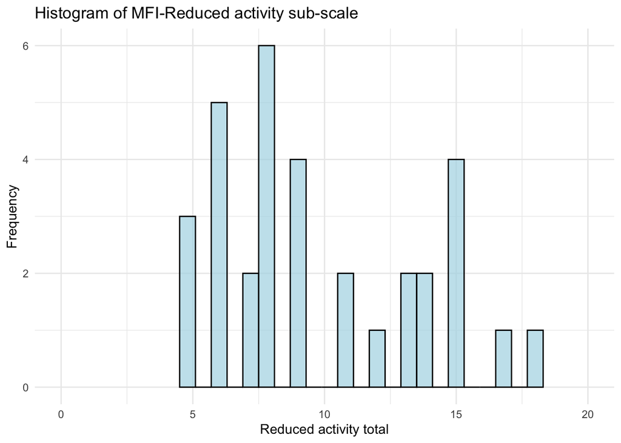

```r
#Reduced activity sub-scale
ggplot(aetv3_questn_tib, aes(x = MFI_redactivity_sum_v3)) +
  geom_histogram(binwidth = 0.6, fill = "lightblue", color = "black", alpha = 0.7) +
  labs(title = "Histogram of MFI-Reduced activity sub-scale", x = "Reduced activity total", y = "Frequency") +
  coord_cartesian(xlim = c(0,20)) +
  scale_x_continuous(breaks = seq(0, 20, 5)) +
  theme_minimal()
```

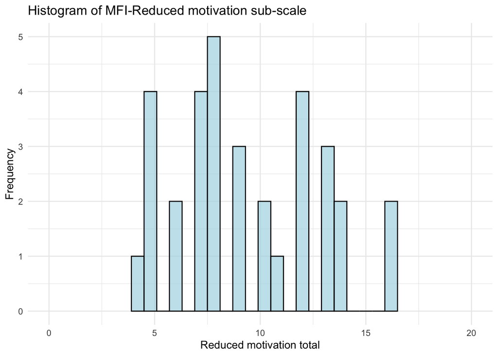

```r
#Reduced motivation sub-scale
ggplot(aetv3_questn_tib, aes(x = MFI_redmotn_sum_v3)) +
  geom_histogram(binwidth = 0.6, fill = "lightblue", color = "black", alpha = 0.7) +
  labs(title = "Histogram of MFI-Reduced motivation sub-scale", x = "Reduced motivation total", y = "Frequency") +
  coord_cartesian(xlim = c(0,20)) +
  scale_x_continuous(breaks = seq(0, 20, 5)) +
  theme_minimal()
```

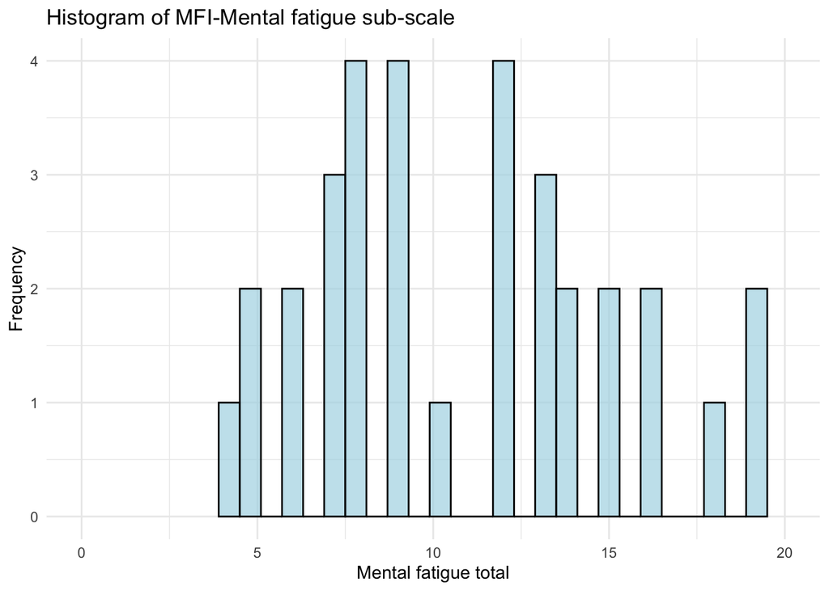

```r
#Mental fatigue sub-scale
ggplot(aetv3_questn_tib, aes(x = MFI_mentalfatigue_sum_v3)) +
  geom_histogram(binwidth = 0.6, fill = "lightblue", color = "black", alpha = 0.7) +
  labs(title = "Histogram of MFI-Mental fatigue sub-scale", x = "Mental fatigue total", y = "Frequency") +
  coord_cartesian(xlim = c(0,20)) +
  scale_x_continuous(breaks = seq(0, 20, 5)) +
  theme_minimal()
```

### Snaith-Hamilton Pleasure Scale (SHAPS)

```r
#Selecting columns
SHAPS_v3 <- aetv3_questn_tib %>%
  dplyr::select(SHAPS_1:SHAPS_14)

#Recoding the participant responses and adding them up
recode_SHAPS_v3 <- c("Strongly agree" = 0, "Agree" = 0, "Disagree" = 1, "Strongly disagree" = 1)
aetv3_questn_tib <- aetv3_questn_tib %>%
  mutate(across(starts_with("SHAPS_"), ~ifelse(. %in% names(recode_SHAPS_v3), recode_SHAPS_v3[.], .))) %>%
  mutate(across(starts_with("SHAPS_"), as.numeric)) %>%
  mutate(SHAPS_sum_v3 = rowSums(dplyr::select(., starts_with("SHAPS_")), na.rm = TRUE))
```

#### Histograms_SHAPS

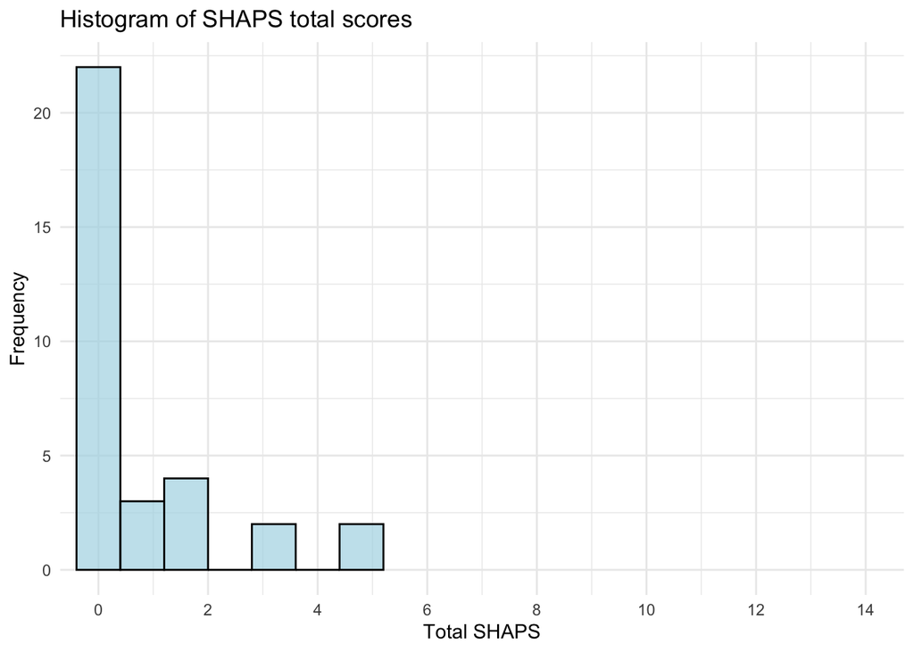

```r
#Full-scale
ggplot(aetv3_questn_tib, aes(x = SHAPS_sum_v3)) +
  geom_histogram(binwidth = 0.8, fill = "lightblue", color = "black", alpha = 0.7) +
  labs(title = "Histogram of SHAPS total scores", x = "Total SHAPS", y = "Frequency") +
  coord_cartesian(xlim = c(0,14)) +
  scale_x_continuous(breaks = seq(0, 14, 2)) +
  theme_minimal()
```

### International Physical activity questionnaire (IPAQ)

[IPAQ](https://ugc.futurelearn.com/uploads/files/bc/c5/bcc53b14-ec1e-4d90-88e3-1568682f32ae/IPAQ_PDF.pdf) : Followed the following steps:

1. Convert all activity to minutes before calculating MET minutes.
2. It is recommended that activity bouts of greater than 3 hours are truncated.
3. To calculate MET minutes a week multiply the MET value given (remember walking = 3.3, moderate activity = 4, vigorous activity = 8) by the minutes the activity was carried out and again by the number of days that that activity was undertaken.
4. Add the MET minutes achieved in each category (walking, moderate activity and vigorous activity) to get total MET minutes of physical activity a week.

```r
#Recoding and scoring
library(stringr)
aetv3_questn_tib <- aetv3_questn_tib %>%
      mutate_at("IPAQ_1", str_replace, "days", "") %>%
      mutate_at("IPAQ_2", str_replace, "days", "") %>%
      mutate_at("IPAQ_3", str_replace, "days", "") %>%
      mutate_at("IPAQ_1", str_replace, "day", "") %>%
      mutate_at("IPAQ_2", str_replace, "day", "") %>%
      mutate_at("IPAQ_3", str_replace, "day", "")


#For the cells with a range, the mid value was used (for eg: "1 to 2 hours" = "90")
#The highest should be 180 mins so, for participants who mentioned more than 3 hrs, I recoded that to 180 mins (as that is the upper limit)

replacements_IPAQ_1a_v3 <- c("between 30 minutes to an hour" = "45", "About 2 hours" = "120", "About 2 Hours" = "120", "1.5 hrs" = "90", "1 hour 30 mins" = "90", "1 hour" = "60", "1hr" = "60", "30 minutes" = "30", "2hrs" = "120", "2hours" = "120", "2 hours" = "120", "4 hours" = "180", "6 hours" = "180", "8 hours" = "180", "45 minutes" = "45", "75 minutes" = "75")

replacements_IPAQ_2a_v3 <- c("between 30 minutes to an hour" = "45", "1-2 hrs" = "90","1 hour and 45 minutes" = "105", "1hour" = "60", "1 hour" = "60", "45 mins" = "45", "1hr" = "60", "1 hours" = "60", "30 min" = "30", "3 hours" = "180", "20 mins" = "20", "30 minutes" = "30", "1" = "60", "30 hour" = "30", "5 hours" = "180", "8" = "180", "40 minutes" = "40", "4 hours" = "180")

replacements_IPAQ_3a_v3 <- c("1-2 hours per day" = "90", "1-2 hours" = "90", "Atleast 10 minutes" = "10", "around 40 minutes each day" = "40", "2-4 hrs" = "180", "1hour 30 mins" = "90", "more than 1 hour" = "60", "more than 30min" = "30", "1 hour" = "60", "2 hours" = "120", "1 hr" = "60", "20 minutes" = "20", "30 minutes" = "30", "30 mins" = "30", "15 min" = "15", "40 minutes" = "40", "8" = "180", "7" = "180", "20 mins" = "20", "60 minutes" = "60", "3hours" = "180", "30 min" = "30", "50 minutes" = "50", "5 hours" = "180")

aetv3_questn_tib <- aetv3_questn_tib %>%
  mutate(IPAQ_1a = case_when(IPAQ_1a %in% names(replacements_IPAQ_1a_v3) ~ str_replace_all(IPAQ_1a, setNames(replacements_IPAQ_1a_v3, paste0("\\b", names(replacements_IPAQ_1a_v3), "\\b"))), TRUE ~ IPAQ_1a))

aetv3_questn_tib <- aetv3_questn_tib %>%
  mutate(IPAQ_2a = case_when(IPAQ_2a %in% names(replacements_IPAQ_2a_v3) ~ str_replace_all(IPAQ_2a, setNames(replacements_IPAQ_2a_v3, paste0("\\b", names(replacements_IPAQ_2a_v3), "\\b"))), TRUE ~ IPAQ_2a))

aetv3_questn_tib <- aetv3_questn_tib %>%
  mutate(IPAQ_3a = case_when(IPAQ_3a %in% names(replacements_IPAQ_3a_v3) ~ str_replace_all(IPAQ_3a, setNames(replacements_IPAQ_3a_v3, paste0("\\b", names(replacements_IPAQ_3a_v3), "\\b"))), TRUE ~ IPAQ_3a))

#Calculating MET for each activity
aetv3_questn_tib <- aetv3_questn_tib %>%
  mutate(IPAQ_1 = as.numeric(IPAQ_1),
    IPAQ_1a = as.numeric(IPAQ_1a),
    IPAQ_2 = as.numeric(IPAQ_2),
    IPAQ_2a = as.numeric(IPAQ_2a),
    IPAQ_3 = as.numeric(IPAQ_3),
    IPAQ_3a = as.numeric(IPAQ_3a),
    IPAQ_vigorous_v3 = IPAQ_1 * IPAQ_1a * 8,
    IPAQ_moderate_v3 = IPAQ_2 * IPAQ_2a * 4,
    IPAQ_walking_v3 = IPAQ_3 * IPAQ_3a * 3.3)

#Total MET
aetv3_questn_tib <- aetv3_questn_tib %>%
  mutate(IPAQ_MET_v3 = rowSums(dplyr::select(., IPAQ_vigorous_v3, IPAQ_moderate_v3, IPAQ_walking_v3), na.rm = TRUE))
```

## Reliability of the scales

Performing a cronbach’s alpha here to check for the internal consistency of the used scales and their sub-scales.

### AMI

```r
#AMI
AMI_alpha_v3 <- aetv3_questn_tib %>%
  dplyr::select("AMI_1", "AMI_2", "AMI_3", "AMI_4", "AMI_5", "AMI_6", "AMI_7", "AMI_8", "AMI_9", "AMI_10", "AMI_11", "AMI_12", "AMI_13", "AMI_14", "AMI_15", "AMI_16", "AMI_17", "AMI_18")
ltm::cronbach.alpha(AMI_alpha_v3)
```

```
Cronbach's alpha for the 'AMI_alpha_v3' data-set

Items: 18
Sample units: 33
alpha: 0.785
```

```r
#AMI_ES
AMI_ES_alpha_v3 <- aetv3_questn_tib  %>%
  dplyr::select("AMI_1", "AMI_6", "AMI_7", "AMI_13", "AMI_16", "AMI_18")
ltm::cronbach.alpha(AMI_ES_alpha_v3)
```

```
Cronbach's alpha for the 'AMI_ES_alpha_v3' data-set

Items: 6
Sample units: 33
alpha: 0.537
```

```r
#AMI_SM
AMI_SM_alpha_v3 <- aetv3_questn_tib  %>%
  dplyr::select("AMI_2", "AMI_3", "AMI_4", "AMI_8", "AMI_14", "AMI_17")
ltm::cronbach.alpha(AMI_SM_alpha_v3)
```

```
Cronbach's alpha for the 'AMI_SM_alpha_v3' data-set

Items: 6
Sample units: 33
alpha: 0.817
```

```r
#AMI_BA
AMI_BA_alpha_v3 <- aetv3_questn_tib  %>%
  dplyr::select("AMI_5", "AMI_9", "AMI_10", "AMI_11", "AMI_12", "AMI_15")
ltm::cronbach.alpha(AMI_BA_alpha_v3)
```

```
Cronbach's alpha for the 'AMI_BA_alpha_v3' data-set

Items: 6
Sample units: 33
alpha: 0.748
```

### MFI

```r
#MFI
MFI_alpha_v3 <- aetv3_questn_tib  %>%
  dplyr::select(all_of(MFI_all_v3))
ltm::cronbach.alpha(MFI_alpha_v3)
```

```
Cronbach's alpha for the 'MFI_alpha_v3' data-set

Items: 20
Sample units: 33
alpha: 0.906
```

```r
#MFI_GF
MFI_GF_alpha_v3 <- aetv3_questn_tib  %>%
  dplyr::select(all_of(MFI_genfatigue_v3))
ltm::cronbach.alpha(MFI_GF_alpha_v3)
```

```
Cronbach's alpha for the 'MFI_GF_alpha_v3' data-set

Items: 4
Sample units: 33
alpha: 0.375
```

```r
#MFI_PF
MFI_PF_alpha_v3 <- aetv3_questn_tib  %>%
  dplyr::select(all_of(MFI_phyfatigue_v3))
ltm::cronbach.alpha(MFI_PF_alpha_v3)
```

```
Cronbach's alpha for the 'MFI_PF_alpha_v3' data-set

Items: 4
Sample units: 33
alpha: 0.727
```

```r
#MFI_RA
MFI_RA_alpha_v3 <- aetv3_questn_tib  %>%
  dplyr::select(all_of(MFI_redactivity_v3))
ltm::cronbach.alpha(MFI_RA_alpha_v3)
```

```
Cronbach's alpha for the 'MFI_RA_alpha_v3' data-set

Items: 4
Sample units: 33
alpha: 0.778
```

```r
#MFI_RM
MFI_RM_alpha_v3 <- aetv3_questn_tib  %>%
  dplyr::select(all_of(MFI_redmotn_v3))
ltm::cronbach.alpha(MFI_RM_alpha_v3)
```

```
Cronbach's alpha for the 'MFI_RM_alpha_v3' data-set

Items: 4
Sample units: 33
alpha: 0.576
```

```r
#MFI_MF
MFI_MF_alpha_v3 <- aetv3_questn_tib  %>%
  dplyr::select(all_of(MFI_mentalfatigue_v3))
ltm::cronbach.alpha(MFI_MF_alpha_v3)
```

```
Cronbach's alpha for the 'MFI_MF_alpha_v3' data-set

Items: 4
Sample units: 33
alpha: 0.858
```

### SHAPS

```r
#SHAPS
SHAPS_alpha_v3 <- aetv3_questn_tib  %>%
  dplyr::select(SHAPS_1:SHAPS_14)
ltm::cronbach.alpha(SHAPS_alpha_v3)
```

```
Cronbach's alpha for the 'SHAPS_alpha_v3' data-set

Items: 14
Sample units: 33
alpha: 0.687
```

### IPAQ

Computing an alpha for this does not make sense right?

## Merging the 2 data sets

Performing a left merge (the data sets will be merged by the common column of ‘subject numbers’ in the 2 files) so that, the data from the questionnaires will be merged based on the cleaned effort data. This will drop all the subjects from the questionnaire data that were removed from the effort data during cleaning.

```r
#Removing the same participants as behavioural data from the questionnaires
AET_behandquestn_tib_v3 <- merge(aetv3_beh_tib_acceptrate, aetv3_questn_tib, by.x = "subjectNumber", by.y = "Subject_number", all.x = TRUE, all.y = FALSE)

#Viewing the first 10 rows for reference
AET_behandquestn_tib_v3 %>%
  head(10) %>%
  knitr::kable (digits = 2)
```

| subjectNumber | blockType | shapeEffort | acceptRate | Unique Response Number | Age | Gender | Student | Programme_and_year | AMI | AMI_1 | AMI_2 | AMI_3 | AMI_4 | AMI_5 | AMI_6 | AMI_7 | AMI_8 | AMI_9 | AMI_10 | AMI_11 | AMI_12 | AMI_13 | AMI_14 | AMI_15 | AMI_16 | AMI_17 | AMI_18 | MFI | MFI_1 | … |
| --- | --- | --- | --- | --- | --- | --- | --- | --- | --- | --- | --- | --- | --- | --- | --- | --- | --- | --- | --- | --- | --- | --- | --- | --- | --- | --- | --- | --- | --- | --- |
| 17 | Easy | 0.7 | 0.00 | 966465-966447-117803084 | 29 | Female | Yes | PhD Law 2nd | NA | 0 | 2 | 1 | 1 | 0 | 3 | 1 | 1 | 0 | 0 | 0 | 0 | 0 | 1 | 3 | 1 | 0 | 0 | NA | 2 | … |
| 17 | Easy | 0.4 | 0.79 | 966465-966447-117803084 | 29 | Female | Yes | PhD Law 2nd | NA | 0 | 2 | 1 | 1 | 0 | 3 | 1 | 1 | 0 | 0 | 0 | 0 | 0 | 1 | 3 | 1 | 0 | 0 | NA | 2 | … |
| 17 | Hard | 0.7 | 0.01 | 966465-966447-117803084 | 29 | Female | Yes | PhD Law 2nd | NA | 0 | 2 | 1 | 1 | 0 | 3 | 1 | 1 | 0 | 0 | 0 | 0 | 0 | 1 | 3 | 1 | 0 | 0 | NA | 2 | … |
| 17 | Easy | 0.1 | 1.00 | 966465-966447-117803084 | 29 | Female | Yes | PhD Law 2nd | NA | 0 | 2 | 1 | 1 | 0 | 3 | 1 | 1 | 0 | 0 | 0 | 0 | 0 | 1 | 3 | 1 | 0 | 0 | NA | 2 | … |
| 17 | Hard | 0.4 | 0.96 | 966465-966447-117803084 | 29 | Female | Yes | PhD Law 2nd | NA | 0 | 2 | 1 | 1 | 0 | 3 | 1 | 1 | 0 | 0 | 0 | 0 | 0 | 1 | 3 | 1 | 0 | 0 | NA | 2 | … |
| 17 | Hard | 0.1 | 1.00 | 966465-966447-117803084 | 29 | Female | Yes | PhD Law 2nd | NA | 0 | 2 | 1 | 1 | 0 | 3 | 1 | 1 | 0 | 0 | 0 | 0 | 0 | 1 | 3 | 1 | 0 | 0 | NA | 2 | … |
| 18 | Easy | 0.1 | 1.00 | 966465-966447-117854251 | 25 | Female | Yes | MSc Advanced Computer Science(1st) | NA | 0 | 1 | 1 | 0 | 1 | 2 | 0 | 1 | 1 | 1 | 0 | 0 | 4 | 3 | 1 | 0 | 1 | 0 | NA | 5 | … |
| 18 | Hard | 0.4 | 0.67 | 966465-966447-117854251 | 25 | Female | Yes | MSc Advanced Computer Science(1st) | NA | 0 | 1 | 1 | 0 | 1 | 2 | 0 | 1 | 1 | 1 | 0 | 0 | 4 | 3 | 1 | 0 | 1 | 0 | NA | 5 | … |
| 18 | Hard | 0.7 | 0.00 | 966465-966447-117854251 | 25 | Female | Yes | MSc Advanced Computer Science(1st) | NA | 0 | 1 | 1 | 0 | 1 | 2 | 0 | 1 | 1 | 1 | 0 | 0 | 4 | 3 | 1 | 0 | 1 | 0 | NA | 5 | … |
| 18 | Easy | 0.7 | 0.10 | 966465-966447-117854251 | 25 | Female | Yes | MSc Advanced Computer Science(1st) | NA | 0 | 1 | 1 | 0 | 1 | 2 | 0 | 1 | 1 | 1 | 0 | 0 | 4 | 3 | 1 | 0 | 1 | 0 | NA | 5 | … |

## Mean Plots

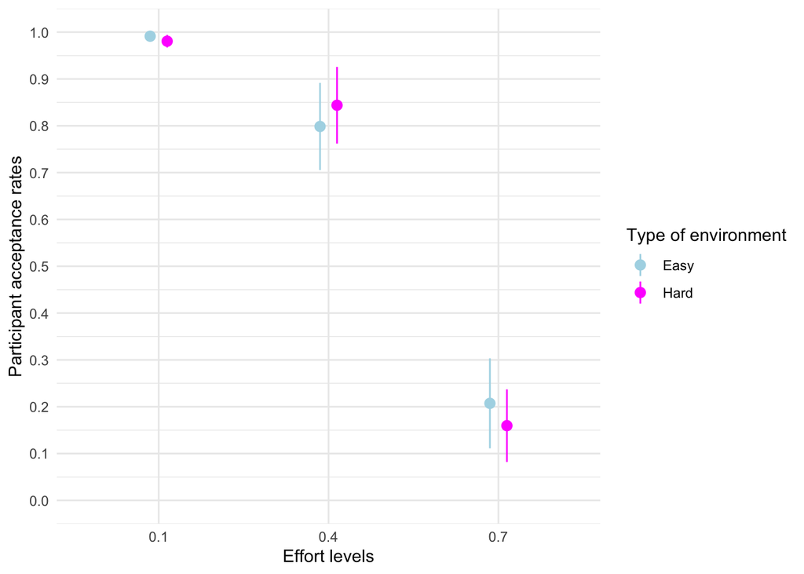

```r
library(Hmisc)

#Mean Plot for effort data
aetv3_plot1 <- ggplot2::ggplot(AET_behandquestn_tib_v3, aes(x = shapeEffort, y= acceptRate, colour = blockType)) +
  stat_summary(fun.data = "mean_cl_normal", geom = "pointrange", position = position_dodge(width = 0.2)) +
  coord_cartesian(ylim = c(0,1)) +
  scale_y_continuous(breaks = seq(0, 1, 0.1)) +
  labs(x = "Effort levels", y = "Participant acceptance rates", colour = "Type of environment") +
  scale_color_manual(values = c("Easy" = "lightblue", "Hard" = "magenta")) +
  theme_minimal()
aetv3_plot1
```

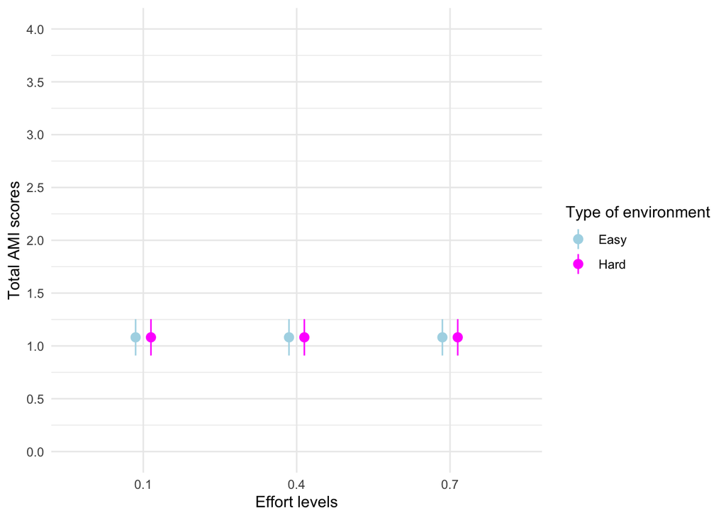

```r
#Mean plot- AMI
aetv3_plot2 <- ggplot2::ggplot(AET_behandquestn_tib_v3, aes(x = shapeEffort, y= AMI_sum_v3, colour = blockType)) +
  stat_summary(fun.data = "mean_cl_normal", geom = "pointrange", position = position_dodge(width = 0.2)) +
  coord_cartesian(ylim = c(0,4)) +
  scale_y_continuous(breaks = seq(0, 4, 0.5)) +
  labs(x = "Effort levels", y = "Total AMI scores", colour = "Type of environment") +
  scale_color_manual(values = c("Easy" = "lightblue", "Hard" = "magenta")) +
  theme_minimal()
aetv3_plot2
```

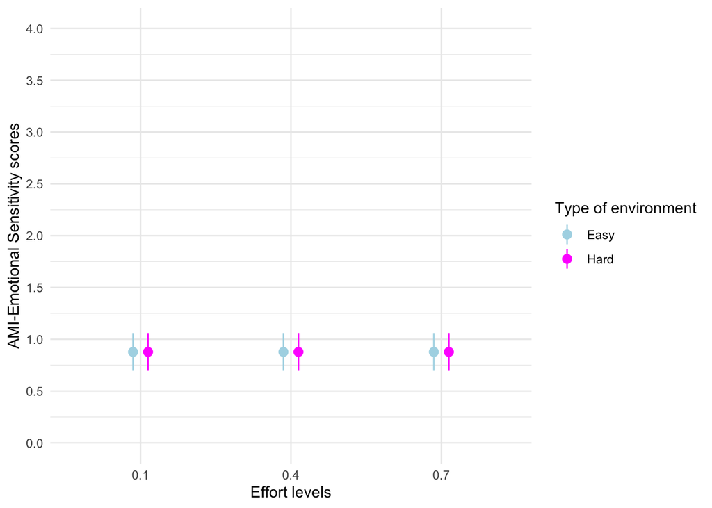

```r
#Mean plot- AMI_ES
aetv3_plot3 <- ggplot2::ggplot(AET_behandquestn_tib_v3, aes(x = shapeEffort, y= AMI_ES_sum_v3, colour = blockType)) +
  stat_summary(fun.data = "mean_cl_normal", geom = "pointrange", position = position_dodge(width = 0.2)) +
  coord_cartesian(ylim = c(0,4)) +
  scale_y_continuous(breaks = seq(0, 4, 0.5)) +
  labs(x = "Effort levels", y = "AMI-Emotional Sensitivity scores", colour = "Type of environment") +
  scale_color_manual(values = c("Easy" = "lightblue", "Hard" = "magenta")) +
  theme_minimal()
aetv3_plot3
```

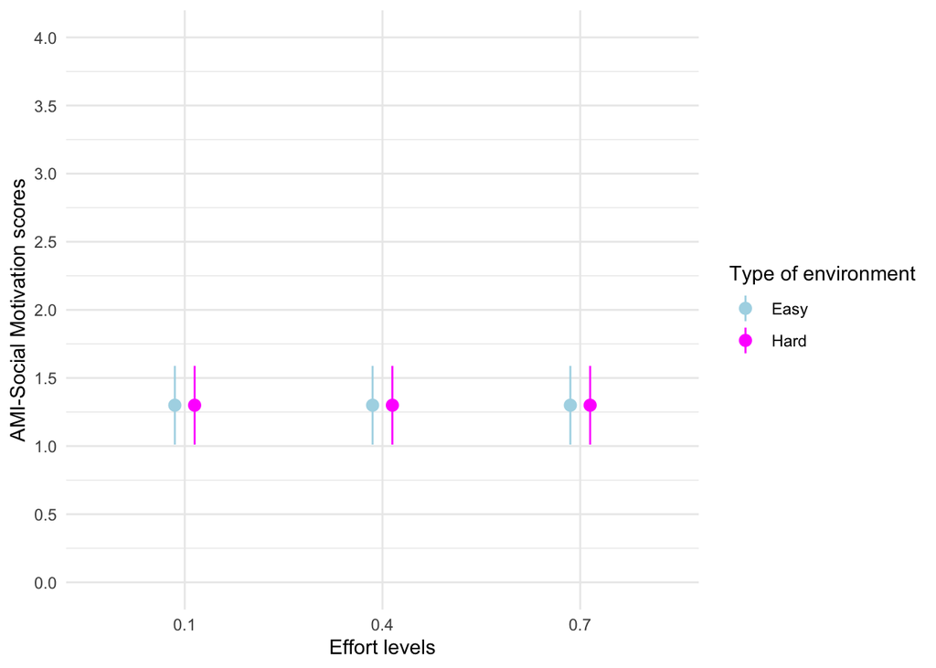

```r
#Mean plot- AMI_SM
aetv3_plot4 <- ggplot2::ggplot(AET_behandquestn_tib_v3, aes(x = shapeEffort, y= AMI_SM_sum_v3, colour = blockType)) +
  stat_summary(fun.data = "mean_cl_normal", geom = "pointrange", position = position_dodge(width = 0.2)) +
  coord_cartesian(ylim = c(0,4)) +
  scale_y_continuous(breaks = seq(0, 4, 0.5)) +
  labs(x = "Effort levels", y = "AMI-Social Motivation scores", colour = "Type of environment") +
  scale_color_manual(values = c("Easy" = "lightblue", "Hard" = "magenta")) +
  theme_minimal()
aetv3_plot4
```

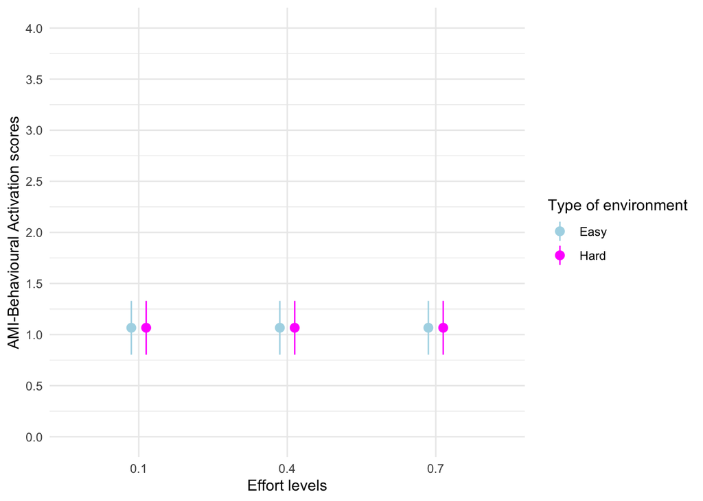

```r
#Mean plot- AMI_BA
aetv3_plot5 <- ggplot2::ggplot(AET_behandquestn_tib_v3, aes(x = shapeEffort, y= AMI_BA_sum_v3, colour = blockType)) +
  stat_summary(fun.data = "mean_cl_normal", geom = "pointrange", position = position_dodge(width = 0.2)) +
  coord_cartesian(ylim = c(0,4)) +
  scale_y_continuous(breaks = seq(0, 4, 0.5)) +
  labs(x = "Effort levels", y = "AMI-Behavioural Activation scores", colour = "Type of environment") +
  scale_color_manual(values = c("Easy" = "lightblue", "Hard" = "magenta")) +
  theme_minimal()
aetv3_plot5
```

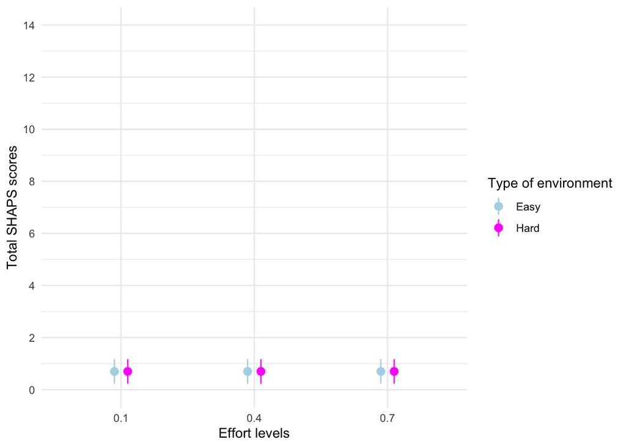

```r
#Mean plot- SHAPS
aetv3_plot6 <- ggplot2::ggplot(AET_behandquestn_tib_v3, aes(x = shapeEffort, y= SHAPS_sum_v3, colour = blockType)) +
  stat_summary(fun.data = "mean_cl_normal", geom = "pointrange", position = position_dodge(width = 0.2)) +
  coord_cartesian(ylim = c(0, 14)) +
  scale_y_continuous(breaks = seq(0, 14, 2)) +
  labs(x = "Effort levels", y = "Total SHAPS scores", colour = "Type of environment") +
  scale_color_manual(values = c("Easy" = "lightblue", "Hard" = "magenta")) +
  theme_minimal()
aetv3_plot6
```

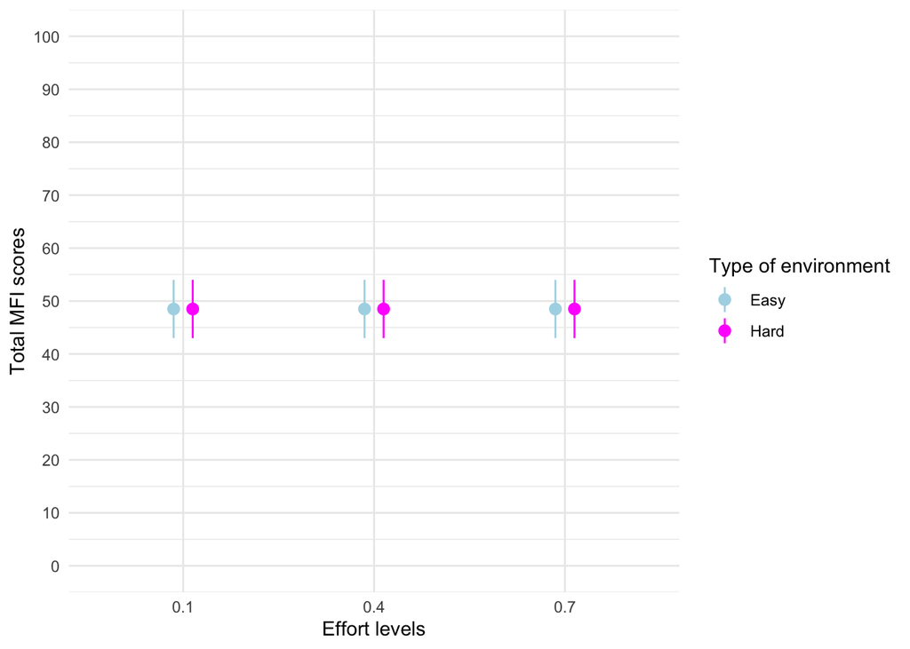

```r
#Mean plot- MFI
aetv3_plot7 <- ggplot2::ggplot(AET_behandquestn_tib_v3, aes(x = shapeEffort, y= MFI_sum_v3, colour = blockType)) +
  stat_summary(fun.data = "mean_cl_normal", geom = "pointrange", position = position_dodge(width = 0.2)) +
  coord_cartesian(ylim = c(0,100)) +
  scale_y_continuous(breaks = seq(0, 100, 10)) +
  labs(x = "Effort levels", y = "Total MFI scores", colour = "Type of environment") +
  scale_color_manual(values = c("Easy" = "lightblue", "Hard" = "magenta")) +
  theme_minimal()
aetv3_plot7
```

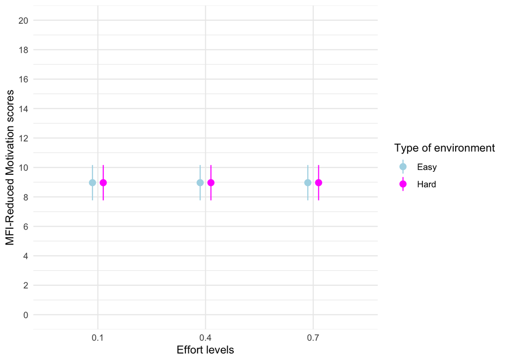

```r
#Mean plot- MFI-reduced motivation
aetv3_plot8 <- ggplot2::ggplot(AET_behandquestn_tib_v3, aes(x = shapeEffort, y= MFI_redmotn_sum_v3, colour = blockType)) +
  stat_summary(fun.data = "mean_cl_normal", geom = "pointrange", position = position_dodge(width = 0.2)) +
  coord_cartesian(ylim = c(0,20)) +
  scale_y_continuous(breaks = seq(0, 20, 2)) +
  labs(x = "Effort levels", y = "MFI-Reduced Motivation scores", colour = "Type of environment") +
  scale_color_manual(values = c("Easy" = "lightblue", "Hard" = "magenta")) +
  theme_minimal()
aetv3_plot8
```

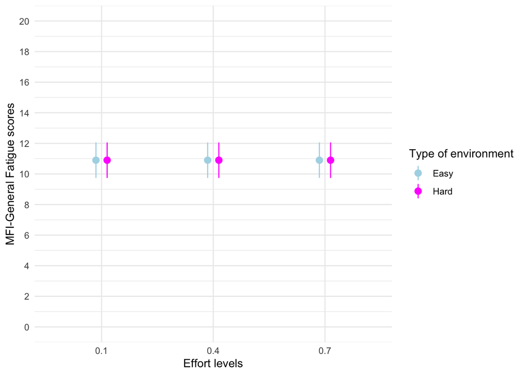

```r
#Mean plot- MFI-general fatigue
aetv3_plot9 <- ggplot2::ggplot(AET_behandquestn_tib_v3, aes(x = shapeEffort, y= MFI_genfatigue_sum_v3, colour = blockType)) +
  stat_summary(fun.data = "mean_cl_normal", geom = "pointrange", position = position_dodge(width = 0.2)) +
  coord_cartesian(ylim = c(0,20)) +
  scale_y_continuous(breaks = seq(0, 20, 2)) +
  labs(x = "Effort levels", y = "MFI-General Fatigue scores", colour = "Type of environment") +
  scale_color_manual(values = c("Easy" = "lightblue", "Hard" = "magenta")) +
  theme_minimal()
aetv3_plot9
```

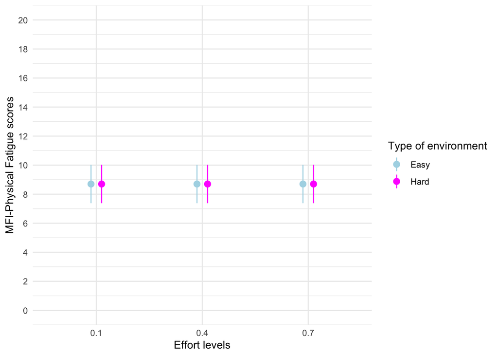

```r
#Mean plot- MFI-physical fatigue
aetv3_plot10 <- ggplot2::ggplot(AET_behandquestn_tib_v3, aes(x = shapeEffort, y= MFI_phyfatigue_sum_v3, colour = blockType)) +
  stat_summary(fun.data = "mean_cl_normal", geom = "pointrange", position = position_dodge(width = 0.2)) +
  coord_cartesian(ylim = c(0,20)) +
  scale_y_continuous(breaks = seq(0, 20, 2)) +
  labs(x = "Effort levels", y = "MFI-Physical Fatigue scores", colour = "Type of environment") +
  scale_color_manual(values = c("Easy" = "lightblue", "Hard" = "magenta")) +
  theme_minimal()
aetv3_plot10
```

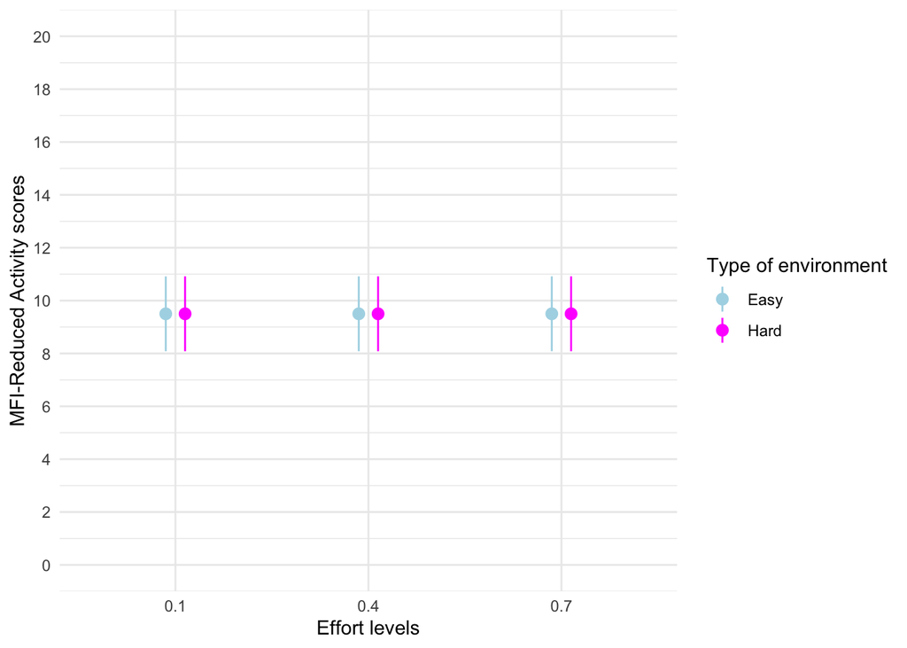

```r
#Mean plot- MFI-reduced activity
aetv3_plot11 <- ggplot2::ggplot(AET_behandquestn_tib_v3, aes(x = shapeEffort, y= MFI_redactivity_sum_v3, colour = blockType)) +
  stat_summary(fun.data = "mean_cl_normal", geom = "pointrange", position = position_dodge(width = 0.2)) +
  coord_cartesian(ylim = c(0,20)) +
  scale_y_continuous(breaks = seq(0, 20, 2)) +
  labs(x = "Effort levels", y = "MFI-Reduced Activity scores", colour = "Type of environment") +
  scale_color_manual(values = c("Easy" = "lightblue", "Hard" = "magenta")) +
  theme_minimal()
aetv3_plot11
```

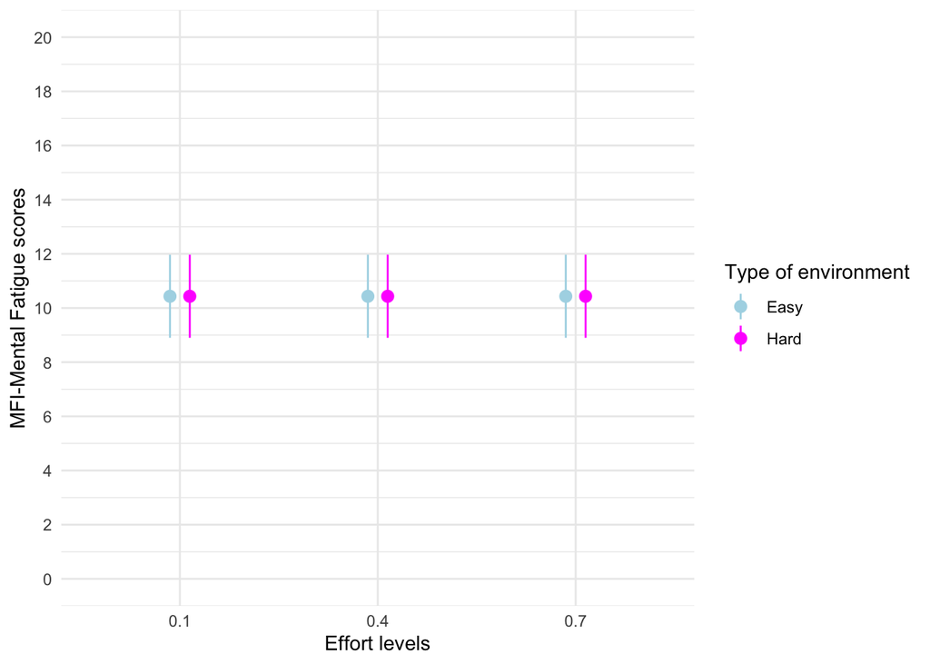

```r
#Mean plot- MFI-mental fatigue
aetv3_plot12 <- ggplot2::ggplot(AET_behandquestn_tib_v3, aes(x = shapeEffort, y= MFI_mentalfatigue_sum_v3, colour = blockType)) +
  stat_summary(fun.data = "mean_cl_normal", geom = "pointrange", position = position_dodge(width = 0.2)) +
  coord_cartesian(ylim = c(0,20)) +
  scale_y_continuous(breaks = seq(0, 20, 2)) +
  labs(x = "Effort levels", y = "MFI-Mental Fatigue scores", colour = "Type of environment") +
  scale_color_manual(values = c("Easy" = "lightblue", "Hard" = "magenta")) +
  theme_minimal()
aetv3_plot12
```

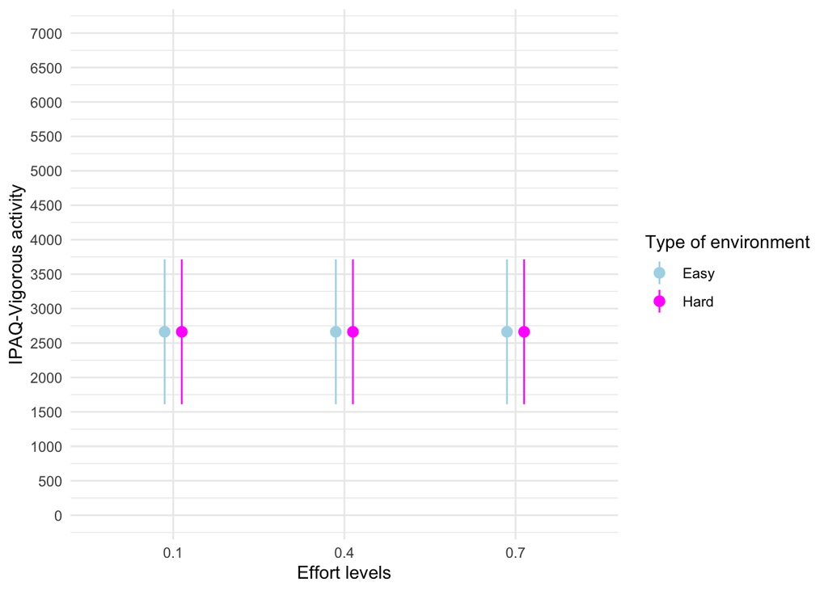

```r
#Mean plot- IPAQ-vigorous
aetv3_plot13 <- ggplot2::ggplot(AET_behandquestn_tib_v3, aes(x = shapeEffort, y= IPAQ_vigorous_v3, colour = blockType), na.rm = T) +
  stat_summary(fun.data = "mean_cl_normal", geom = "pointrange", position = position_dodge(width = 0.2)) +
  coord_cartesian(ylim = c(0,7000)) +
  scale_y_continuous(breaks = seq(0, 7000, 500)) +
  labs(x = "Effort levels", y = "IPAQ-Vigorous activity", colour = "Type of environment") +
  scale_color_manual(values = c("Easy" = "lightblue", "Hard" = "magenta")) +
  theme_minimal()
aetv3_plot13
```

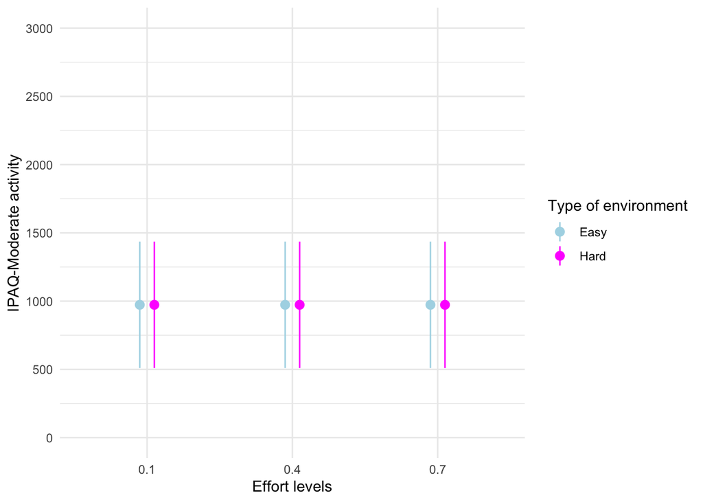

```r
#Mean plot- IPAQ-moderate
aetv3_plot14 <- ggplot2::ggplot(AET_behandquestn_tib_v3, aes(x = shapeEffort, y= IPAQ_moderate_v3, colour = blockType)) +
  stat_summary(fun.data = "mean_cl_normal", geom = "pointrange", position = position_dodge(width = 0.2)) +
  coord_cartesian(ylim = c(0,3000)) +
  scale_y_continuous(breaks = seq(0, 3000, 500)) +
  labs(x = "Effort levels", y = "IPAQ-Moderate activity", colour = "Type of environment") +
  scale_color_manual(values = c("Easy" = "lightblue", "Hard" = "magenta")) +
  theme_minimal()
aetv3_plot14
```

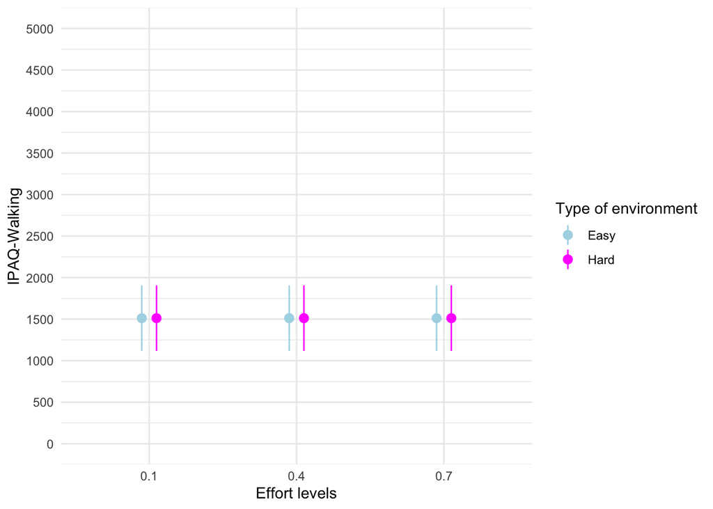

```r
#Mean plot- IPAQ-walking
aetv3_plot15 <- ggplot2::ggplot(AET_behandquestn_tib_v3, aes(x = shapeEffort, y= IPAQ_walking_v3, colour = blockType)) +
  stat_summary(fun.data = "mean_cl_normal", geom = "pointrange", position = position_dodge(width = 0.2)) +
  coord_cartesian(ylim = c(0,5000)) +
  scale_y_continuous(breaks = seq(0, 5000, 500)) +
  labs(x = "Effort levels", y = "IPAQ-Walking", colour = "Type of environment") +
  scale_color_manual(values = c("Easy" = "lightblue", "Hard" = "magenta")) +
  theme_minimal()
aetv3_plot15
```

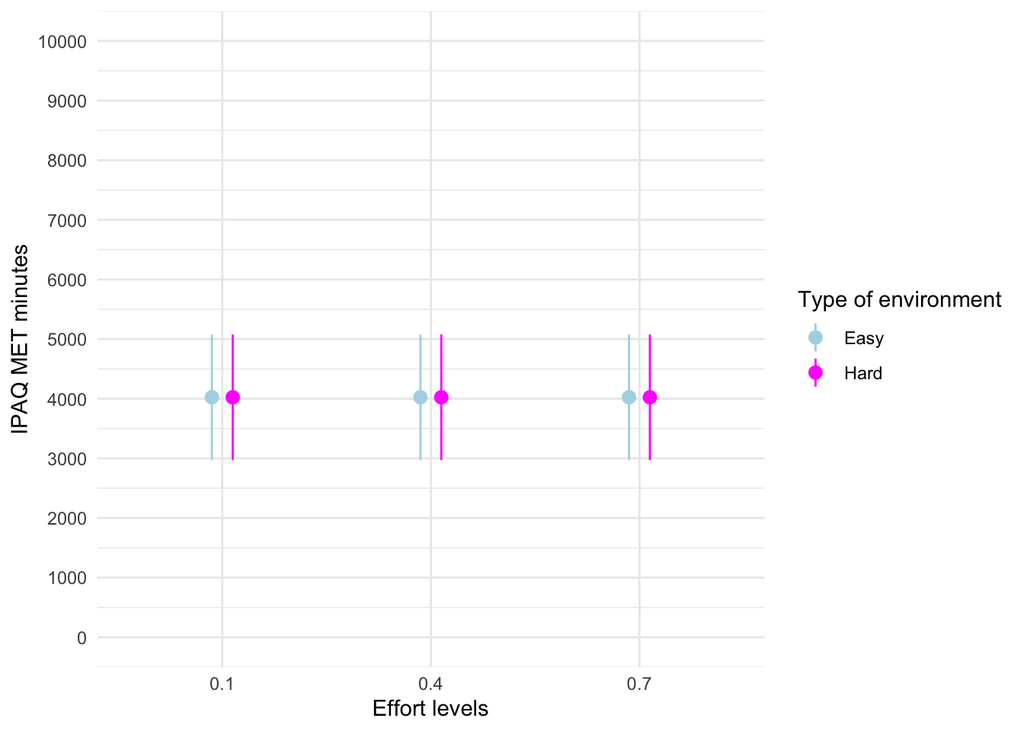

```r
#Mean plot- Total IPAQ-MET
aetv3_plot16 <- ggplot2::ggplot(AET_behandquestn_tib_v3, aes(x = shapeEffort, y= IPAQ_MET_v3, colour = blockType)) +
  stat_summary(fun.data = "mean_cl_normal", geom = "pointrange", position = position_dodge(width = 0.2)) +
  coord_cartesian(ylim = c(0,10000)) +
  scale_y_continuous(breaks = seq(0, 10000, 1000)) +
  labs(x = "Effort levels", y = "IPAQ MET minutes", colour = "Type of environment") +
  scale_color_manual(values = c("Easy" = "lightblue", "Hard" = "magenta")) +
  theme_minimal()
aetv3_plot16
```

## Boxplots

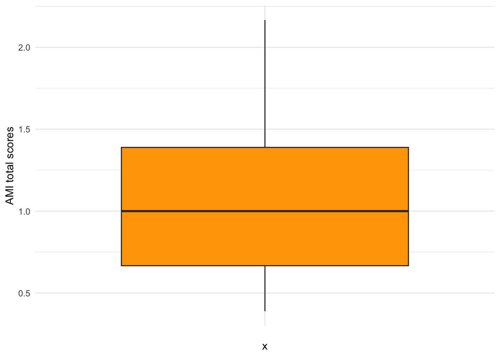

```r
library(ggplot2)

#Total AMI
boxplot1_v3 <- ggplot(AET_behandquestn_tib_v3, aes(x = "", y = AMI_sum_v3)) +
  geom_boxplot(fill = "orange", outlier.colour = "black", outlier.shape = 16, outlier.size = 2) +
  labs(y = "AMI total scores") +
  theme_minimal()
boxplot1_v3
```

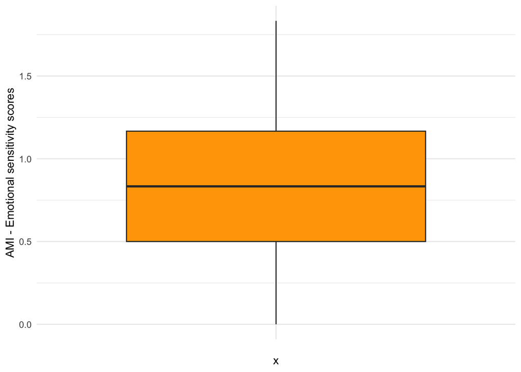

```r
#AMI-ES
boxplot2_v3 <- ggplot(AET_behandquestn_tib_v3, aes(x = "", y = AMI_ES_sum_v3)) +
  geom_boxplot(fill = "orange", outlier.colour = "black", outlier.shape = 16, outlier.size = 2) +
  labs(y = "AMI - Emotional sensitivity scores") +
  theme_minimal()
boxplot2_v3
```

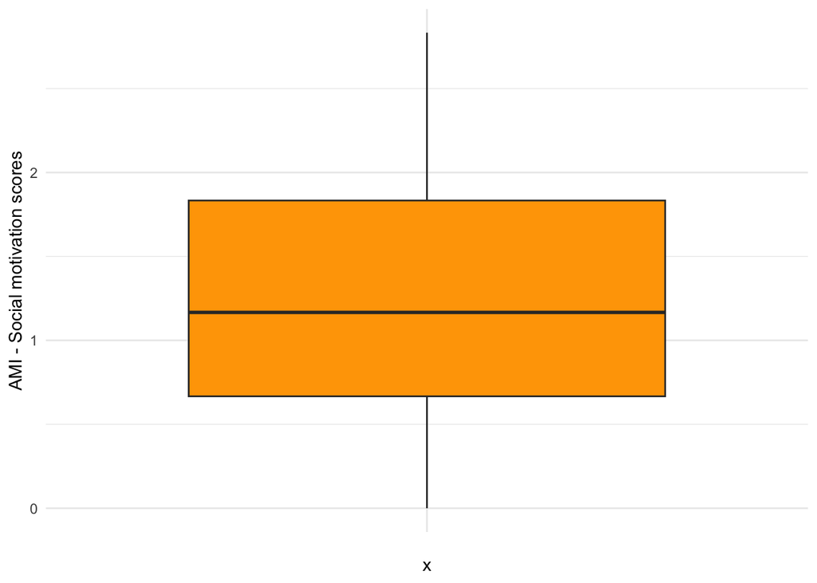

```r
#AMI-SM
boxplot3_v3 <- ggplot(AET_behandquestn_tib_v3, aes(x = "", y = AMI_SM_sum_v3)) +
  geom_boxplot(fill = "orange", outlier.colour = "black", outlier.shape = 16, outlier.size = 2) +
  labs(y = "AMI - Social motivation scores") +
  theme_minimal()
boxplot3_v3
```

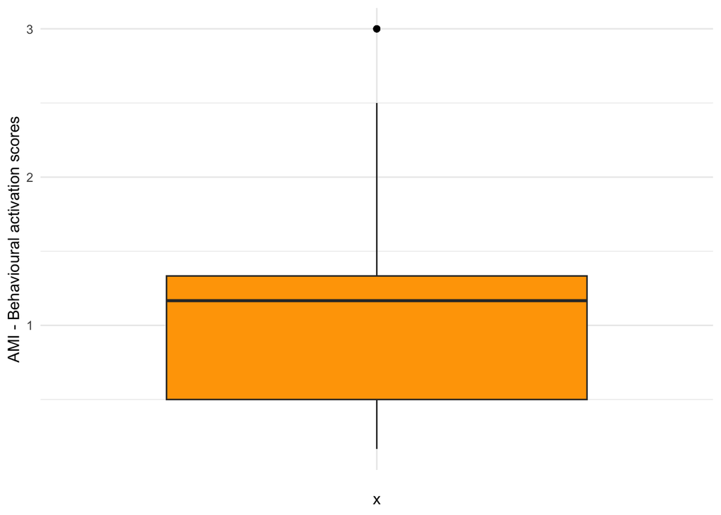

```r
#AMI-BA
boxplot4_v3 <- ggplot(AET_behandquestn_tib_v3, aes(x = "", y = AMI_BA_sum_v3)) +
  geom_boxplot(fill = "orange", outlier.colour = "black", outlier.shape = 16, outlier.size = 2) +
  labs(y = "AMI - Behavioural activation scores") +
  theme_minimal()
boxplot4_v3
```